# Video 1: Bayesian Hypothesis Testing Concept

### Question 3: Why do Bayesian Hypothesis Testing useful?

Up till now we've seen how to conduct Bayesian hypothesis testing to compare male and female candidates in terms of job placement probability and average salary. They are comparative in nature and the advantage of Bayesian estimation are two-fold.

- The Bayesian methods can show you not only the point estimate of how large the group differences such as the average salary are, but also the uncertainty. Knowing the uncertainty really helps us to interpret the reasonable range of results with their associated likelihood.
- The Bayesian methods show the likelihood of the posterior distribution of the hypothesis for every single point given the data, so it helps us to formulate an updated belief not only for the possible values, but also the strength.

In this lecture, you've seen how to test a hypothesis using PyMC3. Bayesian hypothesis testing provides a structured way to quantify logical processes that we do in our daily life. One last minute note is that if you disagree with the prior I provide, it is totally acceptable - then we can observe the same data, but may reach different conclusions. In many situations, the logic of Bayesian thinking is similar to how we think naturally - we update our initial belief by constantly incorporating new evidence. Make sure we've now learnt how to specify problems clearly, execute an appropriate model, customize the posterior plots (e.g. with the `ref_val`, `hdi_prob` and `rope` options to point the null hypothesis quantity as reference value specify the level of credibility and the region of practical significance where the quantities should fall outside such that we can confidently choose in favor of the alternative hypothesis). I hope you enjoy the first Bayesian hypothesis testing example. I'll see you in the next video!

### Acknowledgement

I would like to pay special thanks to Dr. Dhimant Ganatara, who is a Professor at Jain University, for creating this dataset in Kaggle that I used it for Bayesian analysis.

# Video 1: Bayes Factor

### Question 1: What is the motivation to introduce Bayes Factor?

In this lecture, we'll discuss another type of hypothesis testing, a proportional type of hypothesis testing we called **Bayes Factor**. We will outline an experiment and obtain Bayes Factor to test competing hypotheses and use posterior distribution results from previous experiments to update prior distributions for subsequent experiments.

In the group comparison video, we have examined the campus recruitment data to find out if gender inequality exists in terms of worker's salary and the chance of job placement. We compared the average salaries and job placement probability between male and female, using the 95% highest posterior density interval as evidence to make our conclusion. Some people in Bayesian statistics, however, prefer comparing competing claims. Rather than comparing gender groups for salary, there is a need to test pairs of competing claims and figure out under which claim we can learn more information from the data.

### Question 2: What is Bayes Factor?

This notion guides us to today's topic - **Bayes Factor**. Introduced by Harold Jeffreys in the 1960s, Bayes factor’ is a Bayesian method of hypothesis testing that expresses the relative odds of two or multiple competing hypotheses, and is usually used to determine which model better fits the data (Jeffreys 1961). **Bayes Factor** is a ratio that represents the amount of information that we've learnt about our competing hypotheses from the data.

```python
# Let's now look at the first few rows of the data again.
placement.head(5)

# In the placement data, we've seen there are some people who have prior working experience and some
# people who have not. We're curious if prior working experience is associated with increased salary
# upon job placement.
```

|  | sl_no | gender | ssc_p | ssc_b | hsc_p | hsc_b | hsc_s | degree_p | degree_t | workex | etest_p | specialisation | mba_p | status | salary |
| --- | --- | --- | --- | --- | --- | --- | --- | --- | --- | --- | --- | --- | --- | --- | --- |
| 0 | 1 | 1 | 67.00 | Others | 91.00 | Others | Commerce | 58.00 | Sci&Tech | 0 | 55.0 | Mkt&HR | 58.80 | 1 | 270000.0 |
| 1 | 2 | 1 | 79.33 | Central | 78.33 | Others | Science | 77.48 | Sci&Tech | 1 | 86.5 | Mkt&Fin | 66.28 | 1 | 200000.0 |
| 2 | 3 | 1 | 65.00 | Central | 68.00 | Central | Arts | 64.00 | Comm&Mgmt | 0 | 75.0 | Mkt&Fin | 57.80 | 1 | 250000.0 |
| 3 | 4 | 1 | 56.00 | Central | 52.00 | Central | Science | 52.00 | Sci&Tech | 0 | 66.0 | Mkt&HR | 59.43 | 0 | NaN |
| 4 | 5 | 1 | 85.80 | Central | 73.60 | Central | Commerce | 73.30 | Comm&Mgmt | 0 | 96.8 | Mkt&Fin | 55.50 | 1 | 425000.0 |

We might have mixed perspectives on this question. In our job market, many production line companies offer higher wages to new hires than they're paying for more senior employees - this is a form of **pay compression**. Other companies like tech companies tend to pay for new hires slightly lower than that of current employees if they both work for the same position. One reason of paying higher salary to new hires is that companies want to attract potential workers to retain and work long term. If we want to compare different hypothesis (say one believes that new hires receive a higher paycheck than senior employees and one believes the opposite), we want to look at the ratio of two hypotheses. We are interested in how much the observation of placement data could change the first belief versus the second belief, regarding whether prior working experience will add assets to one's salary or diminish one's salary.

This is a very typical example of how **Bayes Factor** can compare the probability of competing hypotheses given the data we observed. We extend the notion of wanting to know if the data give evidence to difference of salary distribution due to gender difference (which is an absolute concept), to compare **which prior belief, or which hypothesis** allows you to gain for information from data compared to the competing hypothesis.

### Question 3: How does Bayesian analysis practitioners quantify Bayes Factor to determine the strength of evidence?

The Bayes factor for comparing two models may be approximated as the ratio of the **marginal likelihood** of the data that is compared against two different hypotheses. So instead of computing the posterior distribution of a certain parameter using the Bayes' rule, we need to compute the ratio of two posterior probability of data - the marginal likelihood. In order to calculate the ratio - Bayes Factor, we require the prior distribution of both hypotheses and the posterior distribution sampled by the MCMC algorithms in PyMC3. Now let's look at the graph - how to quantify the strength of evidence by Bayes Factor.

[figure not shown]

- You can see that if Bayes Factor is larger than 1, then the model favors the alternative hypothesis. But only if Bayes Factor goes as large as 30 then we've very strong evidence to claim that the alternative hypothesis is a better choice.
- If Bayes Factor is smaller than 1, then the model favors the null hypothesis. But only if Bayes Factor is as small as 0.03 then we've very evidence that the null hypothesis actually gains more information from the data.

Now let's explore Bayes Factor with an example.

Bayes Factor Source: https://zj-zhang.github.io/2016/12/31/Bayes-Factor/

```python
# Research question: Does gender affect salary?

salary_male = placement[placement['gender'] == 1]['salary'].dropna()
salary_female = placement[placement['gender'] == 0]['salary'].dropna()

# We can assume that male has naturally higher salary to justify the first prior setting, and assume
# that no difference should be found between two genders to justify the second prior setting.
priors = ((300000, 50000, 200000, 50000), (300000, 50000, 300000, 50000))
models = []
traces = []

# Let's create a for loop that takes the priors for mean and standard deviation of male salary, and
# mean and standard deviation of female salary out for each assumption.
for mean_male, sigma_male, mean_female, sigma_female in priors:

    # Again, for each prior, we enwrap the model and use bf_model for the model name
    with pm.Model() as bf_model:

        # We took the model from the last video when we compared the salary distribution between male and female.
        # But this time we substitute the prior values with variables pre-defined with the two assumptions.
        # So for the first model, we model with the prior knowledge that male earns higher (300,000) than female
        # (200,000). For the second model, both genders earn the same salaries (300,000).

        # For both models, we set the standard deviation of salary distribution as 50,000 because the salary
        # can differ among each accepted candidate.
        mu_male = pm.Normal('mu_male', mu = mean_male, sigma = sigma_male)
        mu_female = pm.Normal('mu_female', mu = mean_female, sigma = sigma_female)

        # Likelihood: We also assume that the standard deviation for the actual data that come from each prior
        # setting to be the same. This is because now we're not interested in comparing the notions of how
        # uncertain the estimates of salaries between genders are. We're only comparing the difference in using
        # "gender-equality" prior and "gender-inequality" prior in order to understand which prior setting
        # brings about significantly more information to the model fit.
        y_male = pm.Normal('y_male', mu = mu_male, sigma = 10000, observed = salary_male)
        y_female = pm.Normal('y_female', mu = mu_female, sigma = 10000, observed = salary_female)

        # Finally, to obtain Bayes Factor, we use the sequential monte carlo sampler instead of the default
        # NUTS sampler - so the result that we'll get includes not only the posterior mean or variance, but
        # also an estimation of the marginal likelihood.
        trace = pm.sample_smc(3000)

        # Let's append the model result and the trace object to the list we've defined at the beginning.
        models.append(bf_model)
        traces.append(trace)

    # Note that the advantage of sequential monte carlo sampler is that it can even compute the marginal
    # likelihood without knowing the closed-form mathematical expression. But the cost of it is that it
    # is less efficient compared to NUTS.
```

[output not shown]

```python
# Cool! Now let's do some Bayes Factor inference. We can compute the Bayes Factor by
# subtracting the log-likelihood between two models, and then take its exponential value by the np.exp function.
BF_smc = np.exp(traces[0].report.log_marginal_likelihood - traces[1].report.log_marginal_likelihood)
BF_smc

# We can see that the Bayes Factors are smaller than 1. I'm surprised about this result! Let's recall the Bayes
# Factor table, it means that there are anecdotal evidence - or weak evidence, that the prior with same salary
# distribution will outperform the prior with differential salary distribution between genders.
# Using an assumption that male earns more than female will give the worse posterior estimates.
# However, how different the posteriors we get from these two models are?
```

```
array([0.51811128, 0.52678248, 0.46620985, 0.51487289])
```

```python
# Let's look at the summary for the model with unequal prior.
az.summary(traces[0]).round(2)
```

|  | mean | sd | hdi_3% | hdi_97% | mcse_mean | mcse_sd | ess_bulk | ess_tail | r_hat |
| --- | --- | --- | --- | --- | --- | --- | --- | --- | --- |
| mu_male | 298911.29 | 1005.05 | 297122.55 | 300910.86 | 9.02 | 6.38 | 12429.0 | 11808.0 | 1.0 |
| mu_female | 267221.49 | 1462.27 | 264475.04 | 269938.47 | 13.30 | 9.40 | 12092.0 | 11481.0 | 1.0 |

```python
# and the summary for the model with equal prior.
az.summary(traces[1]).round(2)

# We might argue that two models are actually very similar even with different priors, and both models
# converge and the posterior estimates are reliable with more than 10,000 effective samples.
```

|  | mean | sd | hdi_3% | hdi_97% | mcse_mean | mcse_sd | ess_bulk | ess_tail | r_hat |
| --- | --- | --- | --- | --- | --- | --- | --- | --- | --- |
| mu_male | 298903.43 | 1007.02 | 297018.45 | 300782.17 | 9.20 | 6.51 | 11967.0 | 11733.0 | 1.0 |
| mu_female | 267321.32 | 1433.62 | 264752.59 | 270118.29 | 13.06 | 9.23 | 12056.0 | 11930.0 | 1.0 |

100.00% [100/100 00:01<00:00]

100.00% [100/100 00:01<00:00]

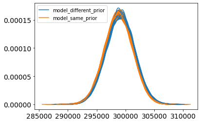

```python
# We can also use the following code to compare the posterior protective of male salary distributions given from
# the assumption that both two prior given to the model. Let's run it directly.

_, ax = plt.subplots()
ppc_0 = pm.sample_posterior_predictive(traces[0], 100, models[0], size = (100, 20))
ppc_1 = pm.sample_posterior_predictive(traces[1], 100, models[1], size = (100, 20))

for m_0, m_1 in zip(ppc_0['y_male'].T, ppc_1['y_male'].T):
    az.plot_kde(np.mean(m_0, 0), ax = ax, plot_kwargs = {"color": "C0"})
    az.plot_kde(np.mean(m_1, 0), ax = ax, plot_kwargs = {"color": "C1"})

ax.plot([], label = "model_different_prior")
ax.plot([], label = "model_same_prior")
ax.legend()
ax.set(xlabel = "male salary prediction")
```

100.00% [100/100 00:01<00:00]

100.00% [100/100 00:01<00:00]

```
[Text(0.5, 0, 'female salary prediction')]
```

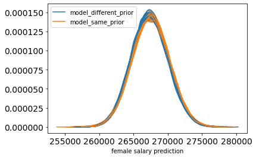

```python
# We can use the same code to compare the posterior protective of female salary distributions given from
# the assumption that both two prior given to the model. Let's run it directly.

_, ax = plt.subplots()
ppc_0 = pm.sample_posterior_predictive(traces[0], 100, models[0], size = (100, 20))
ppc_1 = pm.sample_posterior_predictive(traces[1], 100, models[1], size = (100, 20))

for m_0, m_1 in zip(ppc_0['y_female'].T, ppc_1['y_female'].T):
    az.plot_kde(np.mean(m_0, 0), ax = ax, plot_kwargs = {"color": "C0"})
    az.plot_kde(np.mean(m_1, 0), ax = ax, plot_kwargs = {"color": "C1"})

ax.plot([], label = "model_different_prior")
ax.plot([], label = "model_same_prior")
ax.legend()
ax.set(xlabel = "female salary prediction")
```

Although both models appear to be quite consistent for the salary distribution among different genders. We can still observe that the actual data is more concentrated with the model with the same prior assigned to both genders. We can say that this difference is captured by the Bayes factors, although the evidence is just anecdotal. In this example, we can also see that it is possible to have two different models, with different Bayes factors, but have quite similar predictions. Actually, if the number of observed data is high, it can provide sufficient information to reduce the prior effect on the posterior distribution.

Bayes factor plays a significant role in Bayesian hypothesis testing. We've seen we compared two prior assumptions on the model. But different from standard hypothesis testing, it compute the relative probabilities of the models but not directly measuring the differences. So it's fine that we sometimes feel uncertain that one hypothesis over the two must be true or not. Hopefully you've learnt the techniques and the mindset of using Bayes factor. Let's see each other in the next video!

# Video 4: Model Comparison: Information Criteria

### Question 1: Why do we need to compare models?

We need to determine which station model can best represents the situation amount different choices that we are coming up with. In this lecture, we will going to look at several methods in order to find out the best model among different choices. First we start with information criterion.

### Question 2: What are common methods of comparing Bayesian models? Which method(s) are typically Bayesian?

There are several information criteria in which typically Bayesian statistics are typically used to compare different model specifications. In Bayesian inference, the most common method of assessing the goodness of fit of an estimated statistical model is Deviance Information Criteria (DIC) and the Widely Applicable Information Criterion (WAIC).

DIC may be compared across different models and even different methods, as long as the dependent variable does not change between models, making DIC the most flexible model fit statistic

DIC is valid only when the joint posterior distribution is approximately multivariate normal. Models should be preferred with smaller DIC. Since DIC increases with model complexity (pD or pV), simpler models are preferred.

The Widely Applicable Information Criterion (WAIC) is an information criterion that is more fully Bayesian than DIC. The result of WAIC more closely resembles leave-one-out cross-validation.

### Question 3: How to quantify the difference among models and choose the best one?

when selecting the best models to represent the problem, we typically first choose the one with the smallest information criteria value.

```python
# # Information Criterion: AIC, BIC, DIC and WAIC
# https://docs.pymc.io/notebooks/model_comparison.html

# az.loo function to check the information criteria for the first model.

az.loo(trace, gender_placement_ht)

# You can see that the estimate for elpd_loo is -7.48, with a standard error of 0.58.
# And the probability underlying the loo (Leave one out cross-validation) is 0.53.
# When we compare models, we want to choose the LOO values that is the lowest because this is computed through
# a transformed scale such that the lower values indicate a better fit of the Bayesian model to the actual data.
```

[output not shown]

### DIC, WAIC, WBIC on hypothesis testing tasks

Both DIC and WAIC are related to out-of-sample/generalization prediction. I think this is a general good metric to evaluate models, even when you care more about the parameters than about the predictions. The general idea is that if your model and parameters are a good description of the underlaying phenomena or process that you are studying they should be able to predict unobserved (but observable) future data.

If you get a warning you have a couple of options (besides ignoring them) to use other methods, like use LOO instead of WAIC (or vice versa), use K-fold cross validation, change your model and use one that is more robust. Of course to compare your models you can also add to the mix posterior predictive checks (although this in an in-sample analysis.) and background information. A little bit more about the warnings. Those are based on empirical observations. Is my opinion that we need more work on this, but as this point this the best thing we have. I have been thinking in adding tools to help diagnose or at least visualize the problematic points, thanks for reminding me about this! Notice that when using DIC/BPIC you always get a nice result without any warnings (even in assumptions are not met) and that could lead to overconfidence!

DIC assumes the Posterior is Gaussian, the more you move away from this assumption the more misleading the values of DIC will be. Someone corrects if I am wrong, but is my understanding that hierarchical models tend to have non-gaussian Posteriors. Also WAIC is more Bayesian because you are averaging over the posterior distribution.

I hope you've gained a fundamental understanding about Bayesian hypothesis testing at this point. We've shown two Bayesian hypothesis testing paradigms - 1) **traditional** hypothesis testing through comparing the HPD interval and 2) **proportional** where we compare two competing hypotheses through Bayes Factor. Using the Bayes Factor should be justified in many group research scenarios - whenever a group has not reached consensus on the background knowledge, we might want to test its sensitivity, potential to gain information from the data. Congratulations! Let's continue exploring Bayesian estimation in the next video!